# Regression

Gurjot Padwal

2022-05-06

```r
starbucks <- readRDS(url("https://ericwfox.github.io/data/starbucks.rds"))
```

# **Exercise 2**

## **Part A**

```r
head(starbucks)
```

|  | product_name | calories | total_fat_g | total_carbs_g | sugar_g | caffeine_mg |
| --- | --- | --- | --- | --- | --- | --- |
| 1 | Double Chocolaty Chip Crème Frappuccino Blended | 410 | 12 | 71 | 65 | 20 |
| 2 | Iced Coffee with milk | 110 | 1 | 22 | 21 | 125 |
| 3 | London Fog Tea Latte | 180 | 4 | 30 | 30 | 40 |
| 4 | Skinny Mocha | 210 | 2 | 30 | 19 | 150 |
| 5 | Iced Caffè Mocha | 410 | 15 | 65 | 61 | 110 |
| 6 | Vanilla Bean Crème Frappuccino Blended | 400 | 16 | 59 | 57 | 0 |

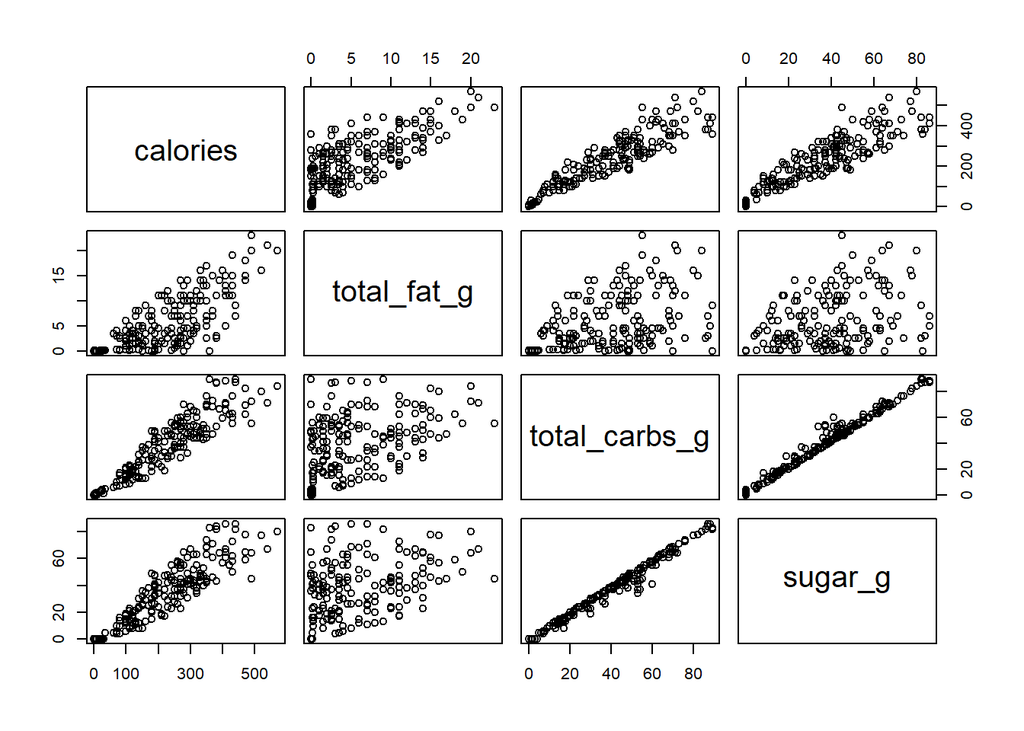

```r
pairs(calories ~ total_fat_g + total_carbs_g + sugar_g, starbucks)
```

```r
round(cor(starbucks[2:5]), 2)
```

```
##               calories total_fat_g total_carbs_g sugar_g
## calories          1.00        0.76          0.92    0.91
## total_fat_g       0.76        1.00          0.48    0.47
## total_carbs_g     0.92        0.48          1.00    0.99
## sugar_g           0.91        0.47          0.99    1.00
```

Yes there is a strong correlation between multiple variables. Calories has a strong correlation with total carbs and total sugars. There is a lower but still strong correlation between total fat and calories. There is also a very strong correlation between total carbs and sugar.

## **Part B**

```r
lm1 = lm(calories ~ total_fat_g + total_carbs_g + sugar_g, starbucks)
summary(lm1)
```

```
##
## Call:
## lm(formula = calories ~ total_fat_g + total_carbs_g + sugar_g,
##     data = starbucks)
##
## Residuals:
##     Min      1Q  Median      3Q     Max
## -33.967 -10.970  -3.667  10.298  54.821
##
## Coefficients:
##               Estimate Std. Error t value Pr(>|t|)
## (Intercept)     9.3439     2.1738   4.298 2.71e-05 ***
## total_fat_g    10.1433     0.2472  41.034  < 2e-16 ***
## total_carbs_g   6.5698     0.3517  18.678  < 2e-16 ***
## sugar_g        -2.6109     0.3643  -7.167 1.52e-11 ***
## ---
## Signif. codes:  0 '***' 0.001 '**' 0.01 '*' 0.05 '.' 0.1 ' ' 1
##
## Residual standard error: 16.34 on 196 degrees of freedom
## Multiple R-squared:  0.9855, Adjusted R-squared:  0.9853
## F-statistic:  4432 on 3 and 196 DF,  p-value: < 2.2e-16
```

I find it unusual that the coefficient for sugar is negative given that sugar should increase the number of calories.

## **Part C**

```r
library(faraway)
round(vif(lm1), 2)
```

```
##   total_fat_g total_carbs_g       sugar_g
##          1.30         53.42         52.90
```

The VIFs for total carbs and sugar are far above the cutoff of 5. Both have a standard error 7.3 times larger than it would be without collinearity. ## **Part D**

```r
lm2 = lm(calories ~ total_fat_g + sugar_g, starbucks)
summary(lm2)
```

```
##
## Call:
## lm(formula = calories ~ total_fat_g + sugar_g, data = starbucks)
##
## Residuals:
##     Min      1Q  Median      3Q     Max
## -47.180 -17.805  -7.014  11.151 106.460
##
## Coefficients:
##             Estimate Std. Error t value Pr(>|t|)
## (Intercept) 20.72637    3.47032   5.972 1.07e-08 ***
## total_fat_g 10.61757    0.40893  25.964  < 2e-16 ***
## sugar_g      4.10958    0.09457  43.454  < 2e-16 ***
## ---
## Signif. codes:  0 '***' 0.001 '**' 0.01 '*' 0.05 '.' 0.1 ' ' 1
##
## Residual standard error: 27.18 on 197 degrees of freedom
## Multiple R-squared:  0.9596, Adjusted R-squared:  0.9592
## F-statistic:  2341 on 2 and 197 DF,  p-value: < 2.2e-16
```

```r
round(vif(lm2), 2)
```

```
## total_fat_g     sugar_g
##        1.29        1.29
```

I removed total carbs from the model since it has the highest correlation with the other predictors.

## **Part E**

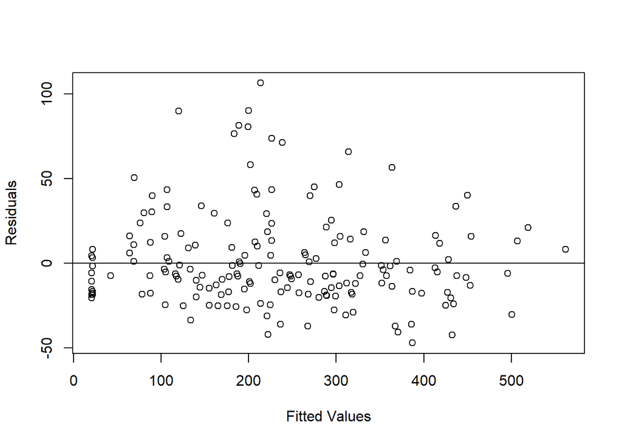

```r
plot(predict(lm2), resid(lm2), xlab="Fitted Values", ylab="Residuals")
abline(h=0)
```

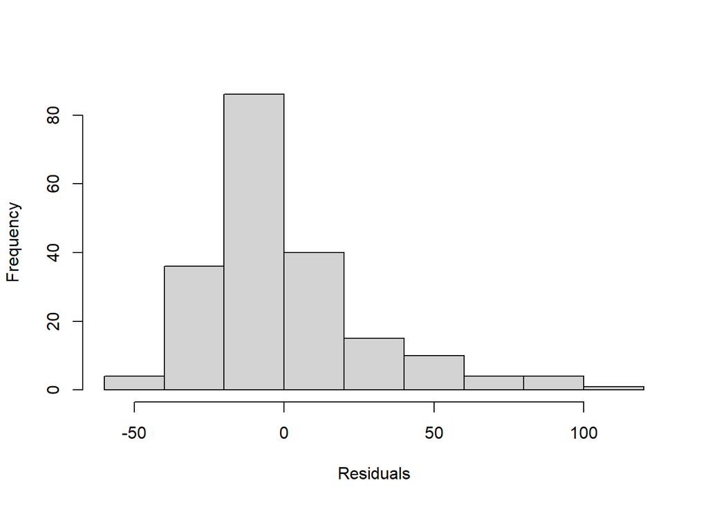

```r
hist(resid(lm2), xlab="Residuals", main="")
```

The scatterplot matrix shows a linear relationship between calories and the predictors. The conditions for MLR seem to be adequately satisfied. There is constant variability in the residual vs. fitted plot. The histogram of residuals is fairly normal with a slight right skew. The data come from a random sample of 200 items from Starbucks, so we can assume independence. About 96 percent of the variablity in calories is explained by total fat and sugar in a Starbucks item.

# **Exercise 3**

```r
county_votes <- readRDS(url("https://ericwfox.github.io/data/county_votes16.rds"))
```

## **Part A**

```r
library("ggplot2")
glm1 = glm(trump_win ~ obama_pctvotes, data = county_votes, family = "binomial")
summary(glm1)
```

```
##
## Call:
## glm(formula = trump_win ~ obama_pctvotes, family = "binomial",
##     data = county_votes)
##
## Deviance Residuals:
##     Min       1Q   Median       3Q      Max
## -3.3777   0.0025   0.0206   0.1159   2.4832
##
## Coefficients:
##                Estimate Std. Error z value Pr(>|z|)
## (Intercept)    20.12971    1.04450   19.27   <2e-16 ***
## obama_pctvotes -0.37149    0.01971  -18.85   <2e-16 ***
## ---
## Signif. codes:  0 '***' 0.001 '**' 0.01 '*' 0.05 '.' 0.1 ' ' 1
##
## (Dispersion parameter for binomial family taken to be 1)
##
##     Null deviance: 2703.37  on 3111  degrees of freedom
## Residual deviance:  736.42  on 3110  degrees of freedom
## AIC: 740.42
##
## Number of Fisher Scoring iterations: 8
```

## **Part B**

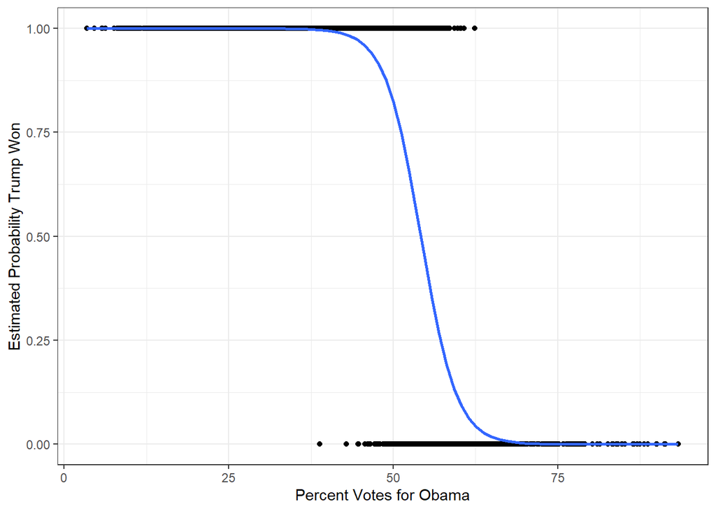

```r
ggplot(county_votes, aes(x = obama_pctvotes, y = trump_win)) + geom_point() + geom_smooth(method = "glm", method.args = list(family = "binomial"), se=F) + xlab("Percent Votes for Obama") +
ylab("Estimated Probability Trump Won") + theme_bw()
```

## **Part C**

```r
new_x = data.frame(obama_pctvotes =40)
predict(glm1, newdata = new_x, type = "response")
```

```
##         1
## 0.9948835
```

```r
new_x = data.frame(obama_pctvotes =50)
predict(glm1, newdata = new_x, type = "response")
```

```
##         1
## 0.8256735
```

```r
new_x = data.frame(obama_pctvotes =60)
predict(glm1, newdata = new_x, type = "response")
```

```
##         1
## 0.1034357
```

Probability Trump Winning with 40 Percent Obama Votes (county) = 99.488% Probability Trump Winning with 50 Percent Obama Votes (county) = 82.567% Probability Trump Winning with 60 Percent Obama Votes (county) = 10.344%

# **Exercise 4**

## **Part A**

```r
glm2 = glm(trump_win ~ pct_pop65 + pct_black + pct_white + pct_hispanic + pct_asian + highschool + bachelors + income, county_votes, family = "binomial")
summary(glm2)
```

```
##
## Call:
## glm(formula = trump_win ~ pct_pop65 + pct_black + pct_white +
##     pct_hispanic + pct_asian + highschool + bachelors + income,
##     family = "binomial", data = county_votes)
##
## Deviance Residuals:
##     Min       1Q   Median       3Q      Max
## -3.2155   0.0648   0.1350   0.3170   2.9283
##
## Coefficients:
##               Estimate Std. Error z value Pr(>|z|)
## (Intercept)   2.760459   1.721412   1.604 0.108802
## pct_pop65    -0.020445   0.017910  -1.142 0.253632
## pct_black    -0.035455   0.007739  -4.581 4.63e-06 ***
## pct_white     0.084759   0.007873  10.765  < 2e-16 ***
## pct_hispanic -0.083716   0.007005 -11.952  < 2e-16 ***
## pct_asian    -0.160999   0.046158  -3.488 0.000487 ***
## highschool   -0.042242   0.020994  -2.012 0.044204 *
## bachelors    -0.193758   0.014444 -13.415  < 2e-16 ***
## income        0.048985   0.008503   5.761 8.39e-09 ***
## ---
## Signif. codes:  0 '***' 0.001 '**' 0.01 '*' 0.05 '.' 0.1 ' ' 1
##
## (Dispersion parameter for binomial family taken to be 1)
##
##     Null deviance: 2703.4  on 3111  degrees of freedom
## Residual deviance: 1269.4  on 3103  degrees of freedom
## AIC: 1287.4
##
## Number of Fisher Scoring iterations: 7
```

Pct_pop65 is not significant to this model fit.

## **Part B**

```r
glm_step = step(glm2)
```

```
## Start:  AIC=1287.42
## trump_win ~ pct_pop65 + pct_black + pct_white + pct_hispanic +
##     pct_asian + highschool + bachelors + income
##
##                Df Deviance    AIC
## - pct_pop65     1   1270.7 1286.7
## <none>              1269.4 1287.4
## - highschool    1   1273.5 1289.5
## - pct_asian     1   1283.6 1299.6
## - pct_black     1   1289.5 1305.5
## - income        1   1304.8 1320.8
## - pct_white     1   1373.3 1389.3
## - pct_hispanic  1   1438.4 1454.4
## - bachelors     1   1489.3 1505.3
##
## Step:  AIC=1286.71
## trump_win ~ pct_black + pct_white + pct_hispanic + pct_asian +
##     highschool + bachelors + income
##
##                Df Deviance    AIC
## <none>              1270.7 1286.7
## - highschool    1   1275.2 1289.2
## - pct_asian     1   1284.0 1298.0
## - pct_black     1   1292.2 1306.2
## - income        1   1310.0 1324.0
## - pct_white     1   1374.5 1388.5
## - pct_hispanic  1   1438.9 1452.9
## - bachelors     1   1489.4 1503.4
```

```r
summary(glm_step)
```

```
##
## Call:
## glm(formula = trump_win ~ pct_black + pct_white + pct_hispanic +
##     pct_asian + highschool + bachelors + income, family = "binomial",
##     data = county_votes)
##
## Deviance Residuals:
##     Min       1Q   Median       3Q      Max
## -3.2004   0.0653   0.1351   0.3205   2.9272
##
## Coefficients:
##               Estimate Std. Error z value Pr(>|z|)
## (Intercept)   2.644244   1.716668   1.540 0.123479
## pct_black    -0.036567   0.007694  -4.753 2.01e-06 ***
## pct_white     0.081996   0.007479  10.963  < 2e-16 ***
## pct_hispanic -0.082609   0.006918 -11.942  < 2e-16 ***
## pct_asian    -0.152133   0.044877  -3.390 0.000699 ***
## highschool   -0.043707   0.020911  -2.090 0.036606 *
## bachelors    -0.192417   0.014389 -13.373  < 2e-16 ***
## income        0.050576   0.008376   6.039 1.56e-09 ***
## ---
## Signif. codes:  0 '***' 0.001 '**' 0.01 '*' 0.05 '.' 0.1 ' ' 1
##
## (Dispersion parameter for binomial family taken to be 1)
##
##     Null deviance: 2703.4  on 3111  degrees of freedom
## Residual deviance: 1270.7  on 3104  degrees of freedom
## AIC: 1286.7
##
## Number of Fisher Scoring iterations: 7
```

## **Part C**

Because the coefficients of pct_black, pct_hispanic, pct_asian, highschool, and bachelors are negative, the increase in x will be associated with a decrease in the probability in Trump winning. Because the coefficients of pct_white and income are positive, the increase in x will be associated with an increase in the probability in Trump winning.